# Practical Machine Learning: Prediction of Manner of Performance in Exercise

nayehi

March 23, 2019

## Introduction

The goal of this project is to build a predictive model for how well a test subject performed barbell lift. This work is undertaken as the final class project in the Practical Machine Learning course. This document is limited to less than 2,000 words and the number of figures is limited to 5.

Background Information:

With devices such as Jawbone Up, Nike FuelBand, and Fitbit, it is possible to collect a large amount of data about personal activity. In the study, six participants performed 10 repetitions of the Unilateral Dumbbell Biceps curl in each of the following five ways: exactly according to the specification (Class A), throwing the elbows to the front (Class B), lifting the dumbbell only halfway (Class C), lowering the dumbbell only halfway (Class D) and throwing the hips to the front (Class E). Data was collected by accelerometers on the belts, forearms, and arms of the participants, as well as the dumbells. More information is available in the “Weight Lifting Exercises Dataset” section of the [Human Activity Recognition page][http://web.archive.org/web/20161224072740/http:/groupware.les.inf.puc-rio.br/har]. The source of this dataset is [Qualitative Activity Recognition of Weight Lifting Exercises][http://web.archive.org/web/20161217164008/http://groupware.les.inf.puc-rio.br/work.jsf?p1=11201] by E. Velloso, A. Bulling, H. Gellersen, W. Ugulino, and H. Fuks.

## Import Data

The data is imported.

```r
training <- read.csv("https://d396qusza40orc.cloudfront.net/predmachlearn/pml-training.csv",header = TRUE)
testing <- read.csv("https://d396qusza40orc.cloudfront.net/predmachlearn/pml-testing.csv",header = TRUE)
```

## Explore Data

The data is explored. The variable to be predicted is “classe,” which records which class of exercise was performed in each observation.

```r
dim(training)
```

```
## [1] 19622   160
```

```r
dim(testing)
```

```
## [1]  20 160
```

```r
head(training)
```

```
##   X user_name raw_timestamp_part_1 raw_timestamp_part_2   cvtd_timestamp
## 1 1  carlitos           1323084231               788290 05/12/2011 11:23
## 2 2  carlitos           1323084231               808298 05/12/2011 11:23
## 3 3  carlitos           1323084231               820366 05/12/2011 11:23
## 4 4  carlitos           1323084232               120339 05/12/2011 11:23
## 5 5  carlitos           1323084232               196328 05/12/2011 11:23
## 6 6  carlitos           1323084232               304277 05/12/2011 11:23
##   new_window num_window roll_belt pitch_belt yaw_belt total_accel_belt
## 1         no         11      1.41       8.07    -94.4                3
## 2         no         11      1.41       8.07    -94.4                3
## 3         no         11      1.42       8.07    -94.4                3
## 4         no         12      1.48       8.05    -94.4                3
## 5         no         12      1.48       8.07    -94.4                3
## 6         no         12      1.45       8.06    -94.4                3
##   kurtosis_roll_belt kurtosis_picth_belt kurtosis_yaw_belt
```

[output cut: 265 more lines]

```r
str(training)
```

```
## 'data.frame':    19622 obs. of  160 variables:
##  $ X                       : int  1 2 3 4 5 6 7 8 9 10 ...
##  $ user_name               : Factor w/ 6 levels "adelmo","carlitos",..: 2 2 2 2 2 2 2 2 2 2 ...
##  $ raw_timestamp_part_1    : int  1323084231 1323084231 1323084231 1323084232 1323084232 1323084232 1323084232 1323084232 1323084232 1323084232 ...
##  $ raw_timestamp_part_2    : int  788290 808298 820366 120339 196328 304277 368296 440390 484323 484434 ...
##  $ cvtd_timestamp          : Factor w/ 20 levels "02/12/2011 13:32",..: 9 9 9 9 9 9 9 9 9 9 ...
##  $ new_window              : Factor w/ 2 levels "no","yes": 1 1 1 1 1 1 1 1 1 1 ...
##  $ num_window              : int  11 11 11 12 12 12 12 12 12 12 ...
##  $ roll_belt               : num  1.41 1.41 1.42 1.48 1.48 1.45 1.42 1.42 1.43 1.45 ...
##  $ pitch_belt              : num  8.07 8.07 8.07 8.05 8.07 8.06 8.09 8.13 8.16 8.17 ...
##  $ yaw_belt                : num  -94.4 -94.4 -94.4 -94.4 -94.4 -94.4 -94.4 -94.4 -94.4 -94.4 ...
##  $ total_accel_belt        : int  3 3 3 3 3 3 3 3 3 3 ...
##  $ kurtosis_roll_belt      : Factor w/ 397 levels "","-0.016850",..: 1 1 1 1 1 1 1 1 1 1 ...
##  $ kurtosis_picth_belt     : Factor w/ 317 levels "","-0.021887",..: 1 1 1 1 1 1 1 1 1 1 ...
##  $ kurtosis_yaw_belt       : Factor w/ 2 levels "","#DIV/0!": 1 1 1 1 1 1 1 1 1 1 ...
```

[output cut: 86 more lines]

```r
colnames(training)
```

```
##   [1] "X"                        "user_name"
##   [3] "raw_timestamp_part_1"     "raw_timestamp_part_2"
##   [5] "cvtd_timestamp"           "new_window"
##   [7] "num_window"               "roll_belt"
##   [9] "pitch_belt"               "yaw_belt"
##  [11] "total_accel_belt"         "kurtosis_roll_belt"
##  [13] "kurtosis_picth_belt"      "kurtosis_yaw_belt"
##  [15] "skewness_roll_belt"       "skewness_roll_belt.1"
##  [17] "skewness_yaw_belt"        "max_roll_belt"
##  [19] "max_picth_belt"           "max_yaw_belt"
##  [21] "min_roll_belt"            "min_pitch_belt"
##  [23] "min_yaw_belt"             "amplitude_roll_belt"
##  [25] "amplitude_pitch_belt"     "amplitude_yaw_belt"
##  [27] "var_total_accel_belt"     "avg_roll_belt"
##  [29] "stddev_roll_belt"         "var_roll_belt"
```

[output cut: 65 more lines]

```r
summary(training$classe)
```

```
##    A    B    C    D    E
## 5580 3797 3422 3216 3607
```

The training data consists of 19622 observations across 160 variables. The testing data consists of 20 observations across the same 160 variables.

## Clean Data

The inclusion of columns unnecessary for the analysis could substantially increase variability, and so these columns are identified and removed.

### Variables Not Affecting the Model

Columns are identified for removal because the type of information they contain does not affect the model.

Column 1 (X) is the row identifier and is not needed. Column 2 (user_name) is not needed for this project. The timestamp columns (3,4,5) also can be removed, since this project does not involve measuring change over time. The window columns (6,7) refer to test specifications not related to performance measures and can be removed.

### NA/Blanks

The str function revealed there are numerous NA values for many variables. These do not provide sufficient data to advise the model and will be removed. All columns for which NA/blanks account for more than 70 percent of the values are removed.

### Near-Zero Variance

Variables with near-zero variance are removed.

```r
TrainData1 <- training[,-c(1:7)]
ColRemove <- which(colSums(is.na(TrainData1)|TrainData1=="")>(0.7*dim(TrainData1)[1]))
TrainData2 <- TrainData1[,-ColRemove]
NZV_cols <- nearZeroVar(TrainData2)
if(length(NZV_cols) >0) {TrainData2 <- TrainData2[,-NZV_cols]}
dim(TrainData2)
```

```
## [1] 19622    53
```

```r
str(TrainData2)
```

```
## 'data.frame':    19622 obs. of  53 variables:
##  $ roll_belt           : num  1.41 1.41 1.42 1.48 1.48 1.45 1.42 1.42 1.43 1.45 ...
##  $ pitch_belt          : num  8.07 8.07 8.07 8.05 8.07 8.06 8.09 8.13 8.16 8.17 ...
##  $ yaw_belt            : num  -94.4 -94.4 -94.4 -94.4 -94.4 -94.4 -94.4 -94.4 -94.4 -94.4 ...
##  $ total_accel_belt    : int  3 3 3 3 3 3 3 3 3 3 ...
##  $ gyros_belt_x        : num  0 0.02 0 0.02 0.02 0.02 0.02 0.02 0.02 0.03 ...
##  $ gyros_belt_y        : num  0 0 0 0 0.02 0 0 0 0 0 ...
##  $ gyros_belt_z        : num  -0.02 -0.02 -0.02 -0.03 -0.02 -0.02 -0.02 -0.02 -0.02 0 ...
##  $ accel_belt_x        : int  -21 -22 -20 -22 -21 -21 -22 -22 -20 -21 ...
##  $ accel_belt_y        : int  4 4 5 3 2 4 3 4 2 4 ...
##  $ accel_belt_z        : int  22 22 23 21 24 21 21 21 24 22 ...
##  $ magnet_belt_x       : int  -3 -7 -2 -6 -6 0 -4 -2 1 -3 ...
##  $ magnet_belt_y       : int  599 608 600 604 600 603 599 603 602 609 ...
##  $ magnet_belt_z       : int  -313 -311 -305 -310 -302 -312 -311 -313 -312 -308 ...
##  $ roll_arm            : num  -128 -128 -128 -128 -128 -128 -128 -128 -128 -128 ...
```

[output cut: 39 more lines]

```r
cor_Train <- cor(TrainData2[,-53])
cor_Train
```

[output not shown]

[output cut: 846 more lines]

[output not shown]

This cleanup has resulted in a better data set for the project.

## Test, Training, and Validation Sets

The training data is split into training (60%) and validation (40%). The validation data will be used to evaluate model fits during tuning.

```r
inTrain <- createDataPartition(TrainData2$classe,p=0.6,list=FALSE)
TrainData <- TrainData2[inTrain,]
ValData <- TrainData2[-inTrain,]
dim(TrainData)
```

```
## [1] 11776    53
```

```r
dim(ValData)
```

```
## [1] 7846   53
```

## Model - Classification Tree

A Classification Tree model is created with 5-fold cross-validation.

```r
set.seed(9999)
ctControl <- trainControl(method="cv",number=5,repeats=1)
```

[figure not shown]

```r
Mod_CT <- train(classe~.,data=TrainData,method="rpart",trControl=ctControl)
fancyRpartPlot(Mod_CT$finalModel)
```

The Classification Tree model is applied to the Validation Data and a confusion matrix is generated.

```r
trainpred <- predict(Mod_CT,newdata=ValData)
confCT <- confusionMatrix(ValData$classe,trainpred)
confCT$table
```

```
##           Reference
## Prediction    A    B    C    D    E
##          A 2040   27  158    0    7
##          B  656  494  368    0    0
##          C  632   46  690    0    0
##          D  563  239  484    0    0
##          E  220  194  396    0  632
```

```r
confCT$overall[1]
```

```
##  Accuracy
## 0.4914606
```

The accuracy for this model is low, indicating the outcome ‘classe’ is not well predicted by the other variables using this model.

## Model - Random Forest

A Random Forest model is created with 5-fold cross-validation.

```r
TrainData$classe <- as.factor(TrainData$classe)
rfControl <- trainControl(method="cv",number=5,repeats=1)
Mod_RF <- train(classe~., data=TrainData, method="rf", trControl=rfControl,verbose=FALSE)
```

The Random Forest model is applied to the Validation Data and a confusion matrix is generated.

```r
trainpred <- predict(Mod_RF,newdata=ValData)
confRF <- confusionMatrix(ValData$classe,trainpred)
confRF
```

```
## Confusion Matrix and Statistics
##
##           Reference
## Prediction    A    B    C    D    E
##          A 2230    1    1    0    0
##          B   13 1501    4    0    0
##          C    0    8 1356    4    0
##          D    0    1   27 1255    3
##          E    0    1    5    4 1432
##
## Overall Statistics
##
##                Accuracy : 0.9908
##                  95% CI : (0.9885, 0.9928)
##     No Information Rate : 0.2859
##     P-Value [Acc > NIR] : < 2.2e-16
##
##                   Kappa : 0.9884
##  Mcnemar's Test P-Value : NA
##
## Statistics by Class:
##
##                      Class: A Class: B Class: C Class: D Class: E
## Sensitivity            0.9942   0.9927   0.9734   0.9937   0.9979
## Specificity            0.9996   0.9973   0.9981   0.9953   0.9984
## Pos Pred Value         0.9991   0.9888   0.9912   0.9759   0.9931
## Neg Pred Value         0.9977   0.9983   0.9943   0.9988   0.9995
## Prevalence             0.2859   0.1927   0.1775   0.1610   0.1829
## Detection Rate         0.2842   0.1913   0.1728   0.1600   0.1825
## Detection Prevalence   0.2845   0.1935   0.1744   0.1639   0.1838
## Balanced Accuracy      0.9969   0.9950   0.9858   0.9945   0.9982
```

The accuracy reflects as 99 percent. However, this may be due to overfitting. A plot will help in the analysis.

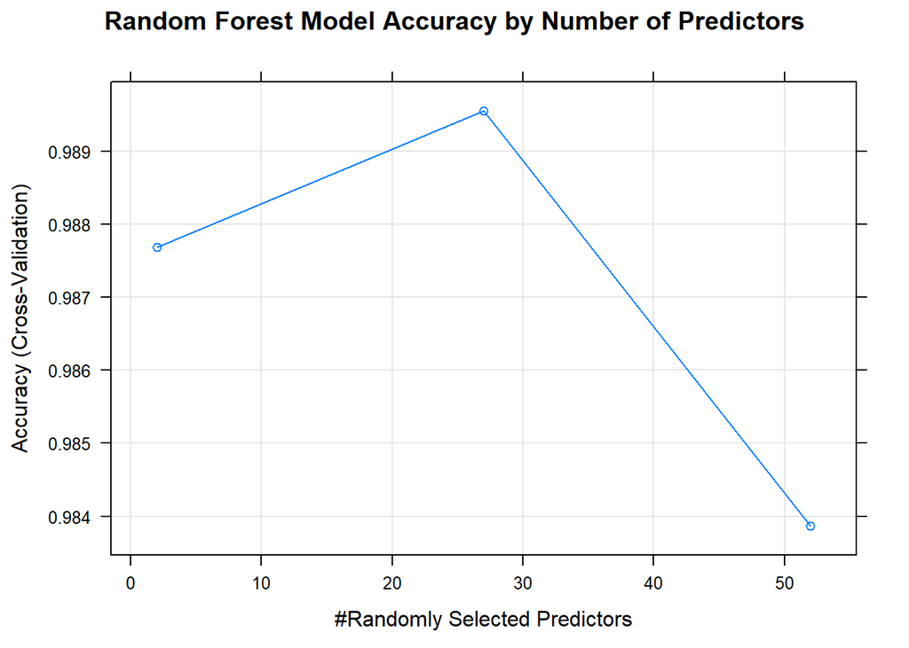

```r
plot(Mod_RF,main="Random Forest Model Accuracy by Number of Predictors")
```

A plot of the confusion matrix.

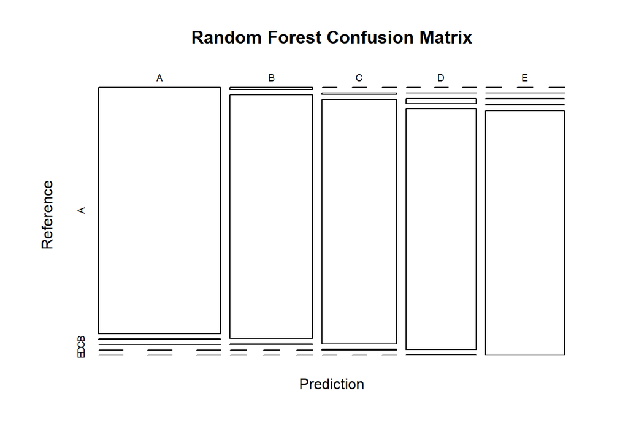

```r
plot(confRF$table, col = confRF$byClass,main=paste("Random Forest Confusion Matrix"))
```

## Model - Generalized Boost Regression Model

A Generalized Boost Regression Model is created with 5-fold cross-validation.

```r
controlGBM <- trainControl(method="cv",number=5,repeats=1)
Mod_GBM <- train(classe~.,data=TrainData,method="gbm",trControl=controlGBM,verbose=FALSE)
Mod_GBM$finalModel
```

```
## A gradient boosted model with multinomial loss function.
## 150 iterations were performed.
## There were 52 predictors of which 52 had non-zero influence.
```

```r
Mod_GBM
```

```
## Stochastic Gradient Boosting
##
## 11776 samples
##    52 predictor
##     5 classes: 'A', 'B', 'C', 'D', 'E'
##
## No pre-processing
## Resampling: Cross-Validated (5 fold)
## Summary of sample sizes: 9420, 9421, 9421, 9420, 9422
## Resampling results across tuning parameters:
##
##   interaction.depth  n.trees  Accuracy   Kappa
##   1                   50      0.7502554  0.6833869
##   1                  100      0.8215025  0.7740896
##   1                  150      0.8536015  0.8147377
##   2                   50      0.8542808  0.8153400
##   2                  100      0.9039571  0.8784120
##   2                  150      0.9305359  0.9120932
##   3                   50      0.8940210  0.8658137
##   3                  100      0.9386034  0.9223066
##   3                  150      0.9588994  0.9479924
##
## Tuning parameter 'shrinkage' was held constant at a value of 0.1
##
## Tuning parameter 'n.minobsinnode' was held constant at a value of 10
## Accuracy was used to select the optimal model using the largest value.
## The final values used for the model were n.trees = 150,
##  interaction.depth = 3, shrinkage = 0.1 and n.minobsinnode = 10.
```

The GMB model is applied to the Validation Data and a confusion matrix is generated.

```r
predict_GBM <- predict(Mod_GBM,newdata=ValData)
confGBM <- confusionMatrix(ValData$classe,predict_GBM)
confGBM
```

```
## Confusion Matrix and Statistics
##
##           Reference
## Prediction    A    B    C    D    E
##          A 2195   23    7    5    2
##          B   45 1432   35    5    1
##          C    0   32 1324   12    0
##          D    0    3   52 1227    4
##          E    2   11   20   24 1385
##
## Overall Statistics
##
##                Accuracy : 0.9639
##                  95% CI : (0.9596, 0.9679)
##     No Information Rate : 0.2858
##     P-Value [Acc > NIR] : < 2.2e-16
##
##                   Kappa : 0.9544
##  Mcnemar's Test P-Value : 1.776e-14
##
## Statistics by Class:
##
##                      Class: A Class: B Class: C Class: D Class: E
## Sensitivity            0.9790   0.9540   0.9207   0.9639   0.9950
## Specificity            0.9934   0.9864   0.9931   0.9910   0.9912
## Pos Pred Value         0.9834   0.9433   0.9678   0.9541   0.9605
## Neg Pred Value         0.9916   0.9891   0.9824   0.9930   0.9989
## Prevalence             0.2858   0.1913   0.1833   0.1622   0.1774
## Detection Rate         0.2798   0.1825   0.1687   0.1564   0.1765
## Detection Prevalence   0.2845   0.1935   0.1744   0.1639   0.1838
## Balanced Accuracy      0.9862   0.9702   0.9569   0.9774   0.9931
```

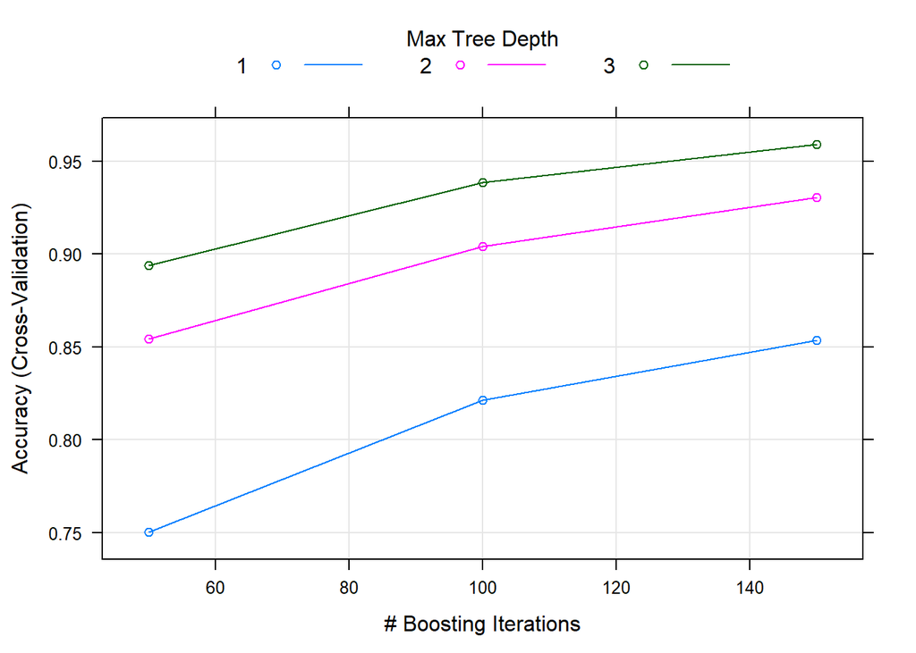

```r
plot(Mod_GBM)
```

```r
TestData <- testing[,-c(1:7)]
ColRemoveTest <- which(colSums(is.na(TestData)|TestData=="")>(0.7*dim(TestData)[1]))
TestData <- TestData[,-ColRemoveTest]
NZV_colsTest <- nearZeroVar(TestData)
if(length(NZV_colsTest) >0) {TestData <- TestData[,-NZV_colsTest]}
dim(TestData)
```

```
## [1] 20 53
```

```r
dim(TrainData)
```

```
## [1] 11776    53
```

```r
dim(ValData)
```

```
## [1] 7846   53
```

```r
dim(TestData)
```

```
## [1] 20 53
```